# Diapositivas · Capítulo 5 — Intensidad por núcleos · Estadística Espacial

← Índice

Universidad El Bosque

Estadística Espacial

Sesión 1 de 2 · 90 min

# Intensidad por núcleos

Estimar la intensidad: núcleo, ancho de banda, borde, mapa y cociente

Estimador núcleoAncho de bandaSelectoresCorrección de bordeMapa de calorIntensidad relativa

**Javier Mauricio Sierra**

Universidad El Bosque

Estadística Espacial

Capítulo 5 · Intensidad por núcleos

De contar a suavizar

Núcleo y ancho de banda: dos decisiones

Selectores de ancho de banda

Corrección de borde en la KDE

La KDE como mapa de calor

Intensidad relativa

Cierre y práctica

Hoja de ruta

## Lo que vamos a construir hoy

Objetivo de la sesión

Una superficie de intensidad es la respuesta a una pregunta que alguien formuló: con qué ancho, con qué corrección de borde y sobre qué ventana. Hoy se aprende dónde vive cada una de esas decisiones y qué dice —y qué no dice— un mapa de calor o de proporción.

Estimador núcleoAncho de bandaSelectoresCorrección de bordeMapa de calorIntensidad relativa

2 / 45

Universidad El Bosque

Estadística Espacial

Capítulo 5 · Intensidad por núcleos

De contar a suavizar

Núcleo y ancho de banda: dos decisiones

Selectores de ancho de banda

Corrección de borde en la KDE

La KDE como mapa de calor

Intensidad relativa

Cierre y práctica

01

## De contar a suavizar

El capítulo 4 terminó con una sola cifra para toda la ciudad. La pregunta que un mapa invita a hacer es otra: *dónde*.

Leer en el material: De contar a suavizar

3 / 45

De contar a suavizar

## Una sola cifra para toda la ciudad no dice dónde hay más sedes

El ejemplo que nos acompaña: las sedes de Bogotá

**Qué ilustra:** el paso de «cuántas» a «dónde». **De dónde sale:** la capa de la Secretaría de Educación del Distrito (SED, vía Datos Abiertos Bogotá): 2 209 sedes, de las que **2 107** caen dentro del perímetro urbano; coordenadas en metros. **Por qué importa:** es el hilo colombiano del curso, el mismo del capítulo 4.

Dato

$$\hat\lambda = \frac{n}{|W|} = \frac{2\,107}{370.09\ \text{km}^2} = 5.69\ \text{sedes/km}^2$$

Interpretación

Un solo número para toda la ventana \(W\): contesta «cuántas por km²», no «dónde». El test de cuadrantes ya empezó a contestar *dónde*: partió la ventana en celdas y contó.

Cómo leer esta clase: **Dato** es una cifra calculada, con su fuente; **Interpretación**, la lectura que se hace de ella; **Criterio**, una postura sobre qué hacer. Fuente: módulo 1 del capítulo.

Capítulo 5 · Intensidad por núcleosEstadística Espacial · UnBosque4 / 45

De contar a suavizar

## Kennedy: 262 sedes en 38.51 km², con un contorno y no con una caja

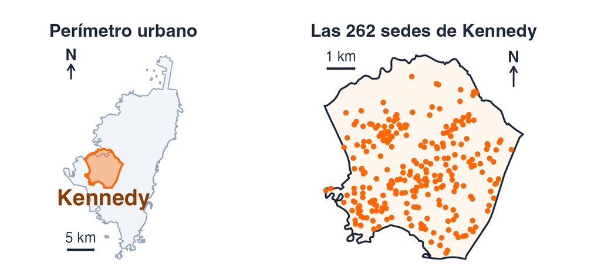

Bogotá y Kennedy, con el norte arriba

La ventana es el contorno, no la caja

```
W <- as.owin(st_union(st_geometry(loc[loc$localidad == "Kennedy", ])))
xy <- st_coordinates(cole)
p <- ppp(xy[, 1], xy[, 2], window = W)   # descarta lo que cae fuera
npoints(p)
#> [1] 262
```

Fuente: módulo 1 del capítulo (R, spatstat, sf).

Kennedy, la ventana de la sesión

**Qué ilustra:** estimar sobre un borde irregular. **De dónde sale:** las sedes de Kennedy, dentro del contorno de la localidad. **Por qué importa:** es la ventana de toda la sesión: sobre ella se varía el ancho y su borde se corrige después.

Dato

\(n\) = **262** · \(|W|\) = **38.51 km²** · \(\hat\lambda\) = 262 / 38.51 = **6.80** por km².

Criterio

Manda la geometría, la que usa `ppp()`: un borde es una decisión.

Capítulo 5 · Intensidad por núcleosEstadística Espacial · UnBosque5 / 45

De contar a suavizar

## Contar en cuadrantes ya estima la intensidad local, con dos defectos

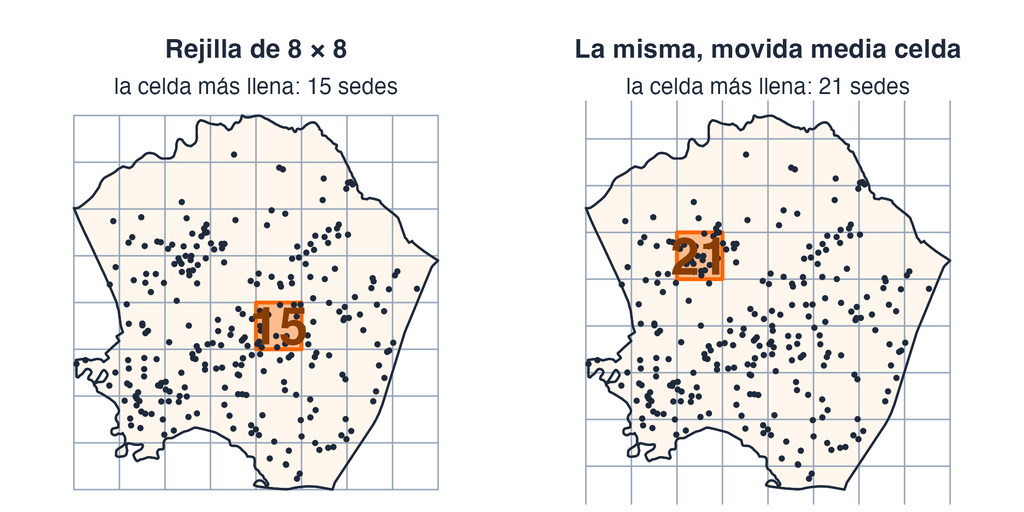

Kennedy con una rejilla de 8 × 8 y con la misma rejilla movida media celda

Fuente: módulo 1 del capítulo (R, spatstat) y figura propia.

Dato

Rejilla de 8 × 8: de **0** a **15** sedes por celda. Movida en pasos de ¼ de celda (16 posiciones), la celda más llena tiene entre **15 y 21**.

Interpretación

**1.** La rejilla la puso alguien (MAUP, capítulo 3): al moverla, la celda más llena pasa de 15 a 21. **2.** Una línea corta la vecindad: una sede a 10 m, al otro lado, no aporta.

Criterio

Si se cuenta en celdas, se publica la rejilla y se prueba a moverla.

Capítulo 5 · Intensidad por núcleosEstadística Espacial · UnBosque6 / 45

De contar a suavizar

## El estimador por núcleos (KDE) suma pesos en vez de contar cajas

$$\hat\lambda(u) \;=\; \frac{1}{e(u)} \sum_{i=1}^{n} k_\sigma\!\left(u - x_i\right)$$

- \(u\): el sitio donde miramos · \(x_i\): las \(n\) sedes
- \(k_\sigma\): el **núcleo**, una función de peso que integra 1 y decae con la distancia
- \(\sigma\): el **ancho de banda**, la desviación típica del núcleo, en metros: hasta dónde llega la influencia de una sede
- \(e(u)\): la **corrección de borde**, la fracción del núcleo que cae dentro de la ventana (la veremos al corregir el borde)

Interpretación

Mismo objetivo que el conteo por cuadrantes, la intensidad local; cambian el peso y la vecindad, no la idea. Cada sede pone una loma y el mapa es la suma de las lomas.

Criterio

σ se elige y se declara como se declaraba el tamaño de celda: ocupa su lugar.

Fuente: módulo 1 del capítulo (fórmula del capítulo).

Capítulo 5 · Intensidad por núcleosEstadística Espacial · UnBosque7 / 45

De contar a suavizar

## Cada sede pone una loma; el mapa es su suma, y σ decide qué tan anchas son

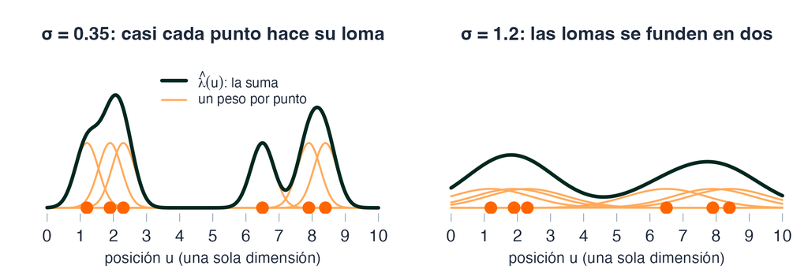

Seis puntos inventados, con dos anchos de banda y la misma escala vertical

Una ilustración, no un dato

**Qué ilustra:** cómo la suma de lomas forma la superficie y cómo σ decide su anchura. **De dónde sale:** seis posiciones inventadas en una dimensión (1.2, 1.9, 2.3, 6.5, 7.9 y 8.4), con núcleo gaussiano. **Por qué importa:** fija la idea antes de medirla en Kennedy.

Interpretación

Con σ pequeño el mapa enseña sedes; con σ grande, zonas: los picos bajan y los valles se llenan, porque cada sede reparte la misma masa en más espacio.

Fuente: ilustración propia, calculada con `dnorm`; no sale del capítulo.

Capítulo 5 · Intensidad por núcleosEstadística Espacial · UnBosque8 / 45

De contar a suavizar

## En 3D: cada punto pone una loma y el mapa es su suma

[interactive chart not shown]

**Qué ilustra:** cómo la suma de lomas forma la superficie y cómo la cambian σ y el núcleo. **De dónde sale:** puntos inventados; es la animación del módulo 1 del capítulo. **Por qué importa:** fija la idea antes de medirla en Kennedy.

Capítulo 5 · Intensidad por núcleosEstadística Espacial · UnBosque9 / 45

Pregunta para la clase

## ¿Qué dos cosas le arregla el estimador por núcleos al conteo por cuadrantes?

1. Que ya no haya que elegir ningún tamaño de vecindad y que el borde de la ventana deje de importar.
2. Que el resultado no dependa de dónde se coloca la rejilla y que las vecindades se solapen.
3. Que la estimación sea insesgada y que no dependa de σ.
4. Que cada sede aporte un peso distinto según su tipo y que la integral devuelva n sin pedírselo.

La 2: sin rejilla que mover, y con vecindades que se solapan

Mover la rejilla cambió la celda más llena de 15 a 21; el núcleo no tiene rejilla, y las vecindades de sedes cercanas se solapan. La 1 es falsa: σ ocupa el lugar del tamaño de celda y el borde importa más, no menos. La 3: σ es justamente la decisión que se discute hoy. La 4 mezcla cosas de otros módulos: el peso por tipo es una marca, y la integral solo devuelve n con una corrección concreta.

Fuente: módulo 12 del capítulo, autoevaluación `cap5-quiz`; opciones reescritas para esta clase.

Capítulo 5 · Intensidad por núcleosEstadística Espacial · UnBosque10 / 45

Universidad El Bosque

Estadística Espacial

Capítulo 5 · Intensidad por núcleos

De contar a suavizar

Núcleo y ancho de banda: dos decisiones

Selectores de ancho de banda

Corrección de borde en la KDE

La KDE como mapa de calor

Intensidad relativa

Cierre y práctica

02

## Núcleo y ancho de banda: dos decisiones

Elegir un estimador por núcleos son dos decisiones: qué función de peso usar y con qué anchura. Suenan igual de importantes. Midámoslas sobre el mismo patrón.

Leer en el material: El ancho de banda lo es todo

11 / 45

Pregunta para la clase

## Antes de medir: ¿cuánto mueve el máximo cambiar el núcleo, y cuánto cambiar el ancho?

Mismas 262 sedes de Kennedy. Cambiamos **una sola cosa** cada vez y miramos cuánto se mueve la **intensidad máxima** del mapa:

- **el núcleo**: `gaussian`, `epanechnikov`, `quartic` y `disc`, con \(\sigma\) = 400 m fijo;
- **el ancho**: un solo núcleo (`gaussian`) y siete valores de \(\sigma\), de 233 a 1867 m.
1. Los dos igual: cada decisión mueve el máximo en torno al 30 %.
2. El núcleo mueve el máximo un 60 % y el ancho, un 5 %.
3. El núcleo mueve el máximo un 5 % y el ancho, un 60 %.
4. Ninguna de las dos pasa del 10 %.

La 3: el ancho, y por mucho

Lo medimos en las dos diapositivas siguientes: el núcleo, un 5.1 %; el ancho, un 66.3 %.

Fuente: módulo 2 del capítulo (R, spatstat).

Capítulo 5 · Intensidad por núcleosEstadística Espacial · UnBosque12 / 45

Núcleo y ancho de banda: dos decisiones

## Cambiar el núcleo mueve el máximo solo un 5.1 %

Dato · Kennedy, 262 sedes

| Núcleo (σ = 400 m) | Máximo (por km²) | Correlación con el gaussiano |
| --- | --- | --- |
| `gaussian` | 18.45 | — |
| `epanechnikov` | 17.51 | 0.9911 |
| `quartic` | 17.69 | 0.9958 |
| `disc` | 17.88 | 0.9647 |

(18.45 − 17.51) / 18.45 = **5.1 %**: máximo menos mínimo, sobre el gaussiano.

Interpretación

Las otras tres superficies correlacionan por encima de 0.96 con la gaussiana: para quien mira el mapa, es el mismo mapa.

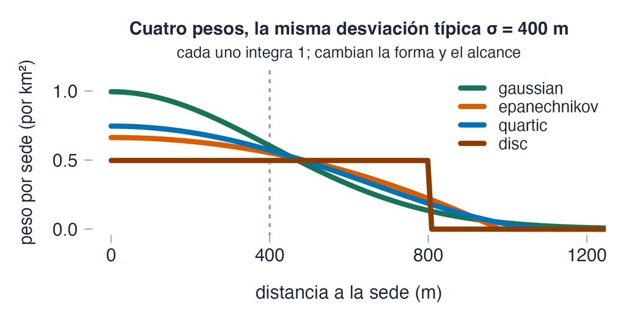

Cuatro núcleos con la misma desviación típica

Criterio

Para comparar núcleos se fijan a la misma **desviación típica**, no al mismo soporte: cada núcleo se escala para que su σ sea la pedida, como en la figura.

Fuente: módulo 2 del capítulo (R, spatstat) y figura propia.

Capítulo 5 · Intensidad por núcleosEstadística Espacial · UnBosque13 / 45

Núcleo y ancho de banda: dos decisiones

## El ancho sí manda: el máximo cae de 29.5 a 9.9 sedes por km² al abrir σ

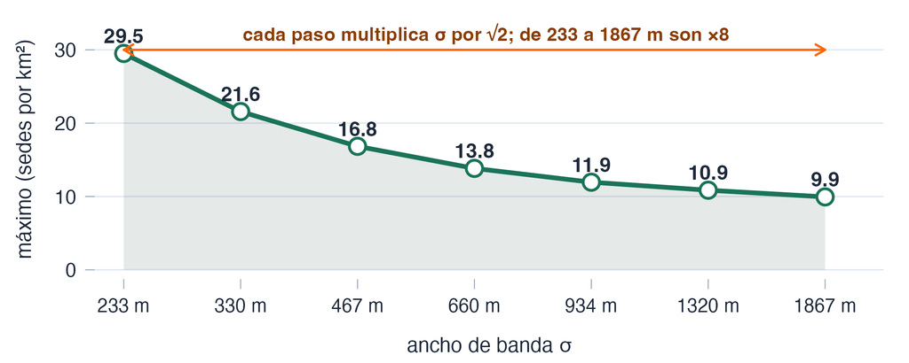

Intensidad máxima contra el ancho de banda

Dato

Kennedy, 262 sedes, núcleo gaussiano, siete anchos de 233 a 1867 m (de uno a otro, ×8). (29.507 − 9.946) / 29.507 = **66.3 %**. El núcleo, a σ = 400 m, movía un 5.1 %.

Criterio

Elegir el núcleo se puede hacer por costumbre; elegir σ decide qué dice el mapa.

Fuente: módulo 2 del capítulo · rejilla de 96 × 99 celdas de 78 m.

Capítulo 5 · Intensidad por núcleosEstadística Espacial · UnBosque14 / 45

Núcleo y ancho de banda: dos decisiones

## Con σ pequeño ves grupos de unas pocas sedes; con σ grande, una sola mancha

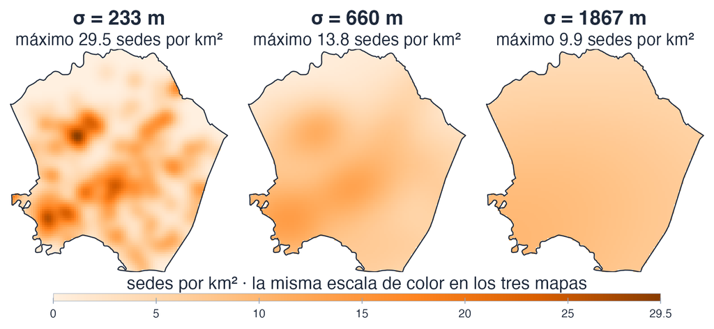

Kennedy con σ = 233, 660 y 1867 m

Interpretación

Con σ = 233 m los focos son grupos de unas pocas sedes: una sola levanta 2.92 por km², una décima del máximo. Con 660 m aparecen zonas; con 1867 m queda una mancha que no distingue barrios. 233 m son **tres celdas** de 78 m: el mínimo para ver el núcleo y no la rejilla.

Criterio

Se publica σ junto al mapa: ninguno de los extremos es un error de cálculo, son la misma estimación con otra anchura.

Fuente: módulo 2 del capítulo. Kennedy, 262 sedes, **una sola escala de color**.

Capítulo 5 · Intensidad por núcleosEstadística Espacial · UnBosque15 / 45

Universidad El Bosque

Estadística Espacial

Capítulo 5 · Intensidad por núcleos

De contar a suavizar

Núcleo y ancho de banda: dos decisiones

Selectores de ancho de banda

Corrección de borde en la KDE

La KDE como mapa de calor

Intensidad relativa

Cierre y práctica

03

## Selectores de ancho de banda

Si el ancho lo decide todo, ¿quién lo decide? R trae varios selectores automáticos; estos cuatro son los más usados, y cada uno devuelve un número. Ese número no es «el ancho óptimo».

Leer en el material: Selectores de ancho de banda

16 / 45

Selectores de ancho de banda

## Cada selector le pregunta algo distinto al patrón (y uno lo contesta con una fórmula)

Dato · Kennedy (262 sedes) y ciudad (2 107 sedes)

Ancho de banda elegido, en metros, con los valores por defecto de cada selector:

| Selector | Qué minimiza o maximiza | Kennedy | Ciudad |
| --- | --- | --- | --- |
| `bw.diggle` | el error cuadrático medio de la intensidad, por validación cruzada · **mira la superficie** | 347.1 | 373.2 |
| `bw.ppl` | la verosimilitud del proceso puntual, dejando un punto fuera cada vez · **mira los puntos** | 374.9 | 235.9 |
| `bw.CvL` | que la suma de \(1/\hat\lambda\) sobre los puntos devuelva el área de la ventana · **mira el área** | 556.7 | 720.4 |
| `bw.scott` | el error cuadrático integrado asintótico, si la intensidad fuera normal: sd · n<sup>−1/6</sup>, en forma cerrada y sin buscar · **mira solo la dispersión y n** | 633.6 | 1251.3 |

Interpretación

Discrepar no es un defecto: a cada selector se le pregunta otra cosa.

Fuente: módulo 3 del capítulo (R, spatstat).

Capítulo 5 · Intensidad por núcleosEstadística Espacial · UnBosque17 / 45

Selectores de ancho de banda

## Por defecto, los selectores discrepan 1.83 veces en Kennedy y 5.30 en la ciudad

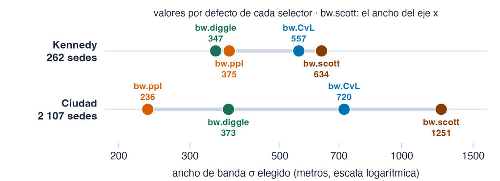

Los cuatro selectores sobre las dos ventanas

Dato

Kennedy: 633.6 / 347.1 = **1.83**. Ciudad: 1251.3 / 235.9 = **5.30**. `bw.scott` devuelve **dos** anchos, uno por eje: 634 y 580 m en Kennedy; 1251 y 2197 m en la ciudad. Las razones usan el del eje x.

Interpretación

En estas dos ventanas, el abanico de los selectores se abre más en la ciudad que en Kennedy.

Fuente: módulo 3 del capítulo (R, spatstat).

Capítulo 5 · Intensidad por núcleosEstadística Espacial · UnBosque18 / 45

Selectores de ancho de banda

## Un selector que devuelve el borde de su intervalo no seleccionó nada

Los pinos japoneses, un patrón de libro

**Qué ilustra:** `bw.ppl` choca con su intervalo: busca el σ que maximiza un criterio, pero solo hasta la mitad del diámetro de la ventana. **De dónde sale:** `japanesepines` (spatstat.data): 65 pinos jóvenes en un cuadrado de 5.7 m (Numata, 1961), reescalado a la unidad. **Por qué importa:** R avisa por consola, pero el número llega hasta el mapa.

El extremo de su propio intervalo

```
round(as.numeric(bw.ppl(japanesepines)), 4)
#> [1] 0.7071

# la mitad de la diagonal de la ventana unidad
diameter(Window(japanesepines)) / 2
#> [1] 0.7071068
```

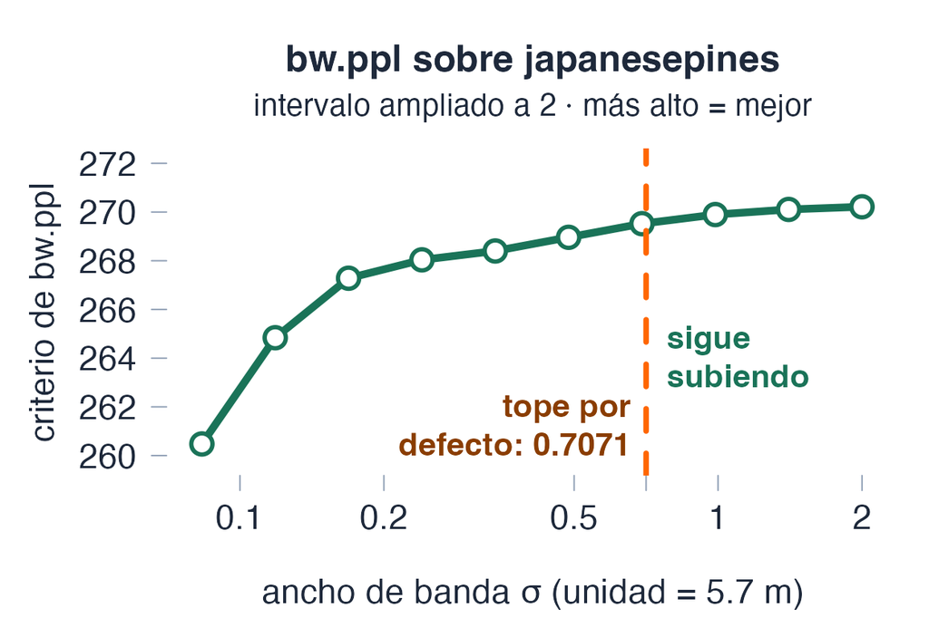

El criterio de bw.ppl, con el intervalo ampliado

Criterio

Un óptimo que coincide con el borde del intervalo, al último decimal, no es un óptimo: es el sitio donde se dejó de buscar. Con el intervalo ampliado el criterio sigue subiendo: la mejor intensidad es una constante.

Fuente: módulo 3 del capítulo (R, spatstat.data).

Capítulo 5 · Intensidad por núcleosEstadística Espacial · UnBosque19 / 45

Pregunta para la clase

## Mismo patrón, dos mapas distintos: ¿quién se equivocó, `bw.diggle` o `bw.scott`?

Dos personas estiman la intensidad del mismo patrón y publican mapas distintos: una usó `bw.diggle` y la otra `bw.scott`.

1. La que usó `bw.scott`, porque es la regla más burda.
2. La que usó `bw.diggle`, porque la validación cruzada es inestable.
3. Ninguna de las dos: cada selector optimiza una cosa distinta.
4. Las dos, porque lo correcto es promediar los cuatro selectores.

La 3: ninguna de las dos

Sobre la ciudad los cuatro selectores dan de 236 a 1251 m, porque cada uno pregunta otra cosa. `bw.scott` es simple, pero eso no lo hace incorrecto; la validación cruzada de `bw.diggle` puede ser inestable, y aquí da un valor razonable. Lo que falta en los dos mapas no es una corrección: es **decir cuál se usó**.

Fuente: módulo 3 del capítulo (R, spatstat), autoevaluación del módulo 6 (`cap5-trampas`).

Capítulo 5 · Intensidad por núcleosEstadística Espacial · UnBosque20 / 45

Idea clave

## Elegir sin decir cuál se eligió es publicar una superficie sin decir qué se le pidió

El ancho de banda se **declara**: cuál selector lo eligió, o por qué ninguno.

Fuente: módulo 3 del capítulo (criterio del autor).

Capítulo 5 · Intensidad por núcleosEstadística Espacial · UnBosque21 / 45

Universidad El Bosque

Estadística Espacial

Capítulo 5 · Intensidad por núcleos

De contar a suavizar

Núcleo y ancho de banda: dos decisiones

Selectores de ancho de banda

Corrección de borde en la KDE

La KDE como mapa de calor

Intensidad relativa

Cierre y práctica

04

## Corrección de borde en la KDE

El núcleo de una sede pegada al borde se sale de la ventana, y la masa que se sale no la recoge nadie. La prueba de que algo va mal no es visual: es una integral.

Leer en el material: Corrección de borde en la KDE

22 / 45

Corrección de borde en la KDE

## El núcleo de una sede pegada al borde se sale de la ventana

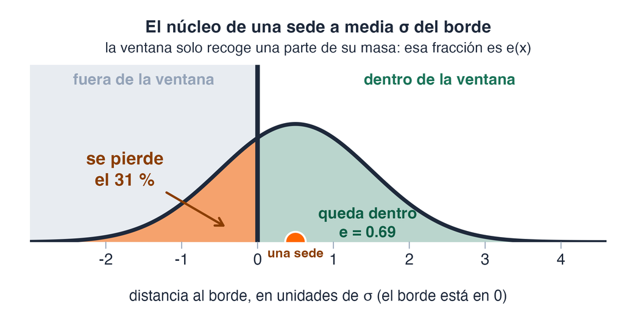

El núcleo de una sede a media σ del borde: dentro de la ventana queda el 69 %

Dato

Ilustración en una dimensión: una sede a 0.5 σ del borde, con σ = 1. Se queda dentro el **69 %** de su núcleo (\(e\) = 0.69) y se sale el **31 %**.

Interpretación

\(e(x)\) es la fracción del núcleo centrado en \(x\) que cae dentro de la ventana. Sin corregir, esa masa se pierde y el mapa baja cerca del borde.

Fuente: ilustración propia, calculada con la normal; el capítulo la aplica a las sedes de Kennedy.

Capítulo 5 · Intensidad por núcleosEstadística Espacial · UnBosque23 / 45

Corrección de borde en la KDE

## Lo que el mapa no deja ver: ¿la integral de \(\hat\lambda\) devuelve n?

$$\int_W \hat\lambda(u)\,du \;\overset{?}{=}\; n$$

### Sin corregir

`edge = FALSE`. El núcleo de una sede en el borde **se sale**, y esa masa se pierde.

### Por defecto

`density(p, sigma)`. `density.ppp` corrige el borde **sin que se lo pidas**.

### Diggle

`diggle = TRUE`. Otra corrección, con el divisor evaluado en otro sitio.

Interpretación

Es una exigencia exacta: conservar el conteo observado. Por eso sirve de prueba de qué conserva cada corrección, no de cuál acierta.

Fuente: módulo 4 del capítulo (texto del capítulo). Ejemplo: Kennedy, 262 sedes.

Capítulo 5 · Intensidad por núcleosEstadística Espacial · UnBosque24 / 45

Corrección de borde en la KDE

## Medido sobre Kennedy: tres correcciones, tres comportamientos

Dato · Kennedy, 262 sedes

Masa integrada por cada corrección y, entre paréntesis, su desviación de n = 262:

| σ (m) | Sin corregir | Por defecto | `diggle = TRUE` |
| --- | --- | --- | --- |
| 200 | 255.08 (−2.64 %) | 263.30 (+0.50 %) | 262.00 (0.0000 %) |
| 400 | 245.86 (−6.16 %) | 265.80 (+1.45 %) | 262.00 (0.0000 %) |
| 800 | 224.41 (−14.35 %) | 270.36 (+3.19 %) | 262.00 (0.0000 %) |

Interpretación

Sin corregir, **la masa se escapa** y cada vez más al abrir el núcleo; por defecto, **en Kennedy se pasa**; con `diggle = TRUE`, n **clavado** a cualquier ancho. Solo una de las tres conserva el conteo, y no es la que sale sin pedirla.

Fuente: módulo 4 del capítulo (R, spatstat).

Capítulo 5 · Intensidad por núcleosEstadística Espacial · UnBosque25 / 45

Corrección de borde en la KDE

## En 3D: lo que se escapa por el borde, y cada corrección

[interactive chart not shown]

**Qué ilustra:** qué hace cada corrección con la masa que se sale de la ventana. **De dónde sale:** puntos inventados, los del módulo 1; no son las sedes de Kennedy. **Por qué importa:** «se pasa» depende de dónde caen los puntos.

Capítulo 5 · Intensidad por núcleosEstadística Espacial · UnBosque26 / 45

Pregunta para la clase

## ¿Se distingue cuál es cuál mirando el mapa?

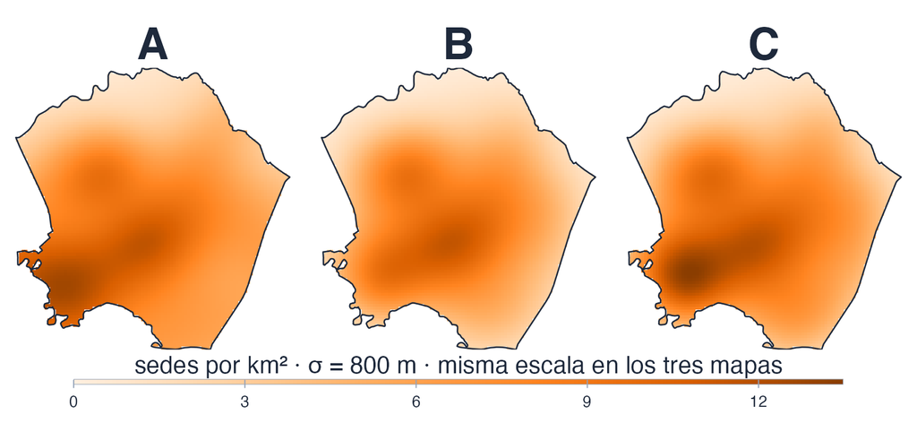

Tres correcciones de borde con σ = 800 m, sin nombre: A, B y C

Kennedy, 262 sedes, σ = 800 m, la misma escala de color. Uno de los tres mapas es el de Diggle y conserva el conteo: ¿cuál es, y se nota mirándolo?

C es la de Diggle

Mirando no se nota que uno conserve el conteo: eso lo dice la integral (A, por defecto, 270.4; B, sin corregir, 224.4; C, Diggle, 262.0). Sí se ven diferencias —el pico más alto es el de Diggle, 13.49 sedes por km², contra 12.66 por defecto y 11.54 sin corregir—, pero ninguna dice cuál es la buena.

Fuente: módulo 4 del capítulo (R, spatstat) y figura propia.

Capítulo 5 · Intensidad por núcleosEstadística Espacial · UnBosque27 / 45

Corrección de borde en la KDE

## Diggle divide donde está el dato; la de por defecto, donde se estima

Por defecto: divide donde se estima

$$\hat\lambda(u) \;=\; \frac{1}{e(u)} \sum_{i=1}^{n} k_\sigma(u - x_i)$$ \(e(v)\) es la fracción del núcleo centrado en \(v\) que cae dentro de la ventana.

Diggle: divide donde está el dato

$$\hat\lambda_D(u) \;=\; \sum_{i=1}^{n} \frac{k_\sigma(u - x_i)}{e(x_i)}$$

Interpretación

Con Diggle cada sede aporta a la integral \(e(x_i)/e(x_i) = 1\): el total es \(n\) **por construcción**. Las dos son legítimas; solo una conserva el conteo.

Criterio

Se declara cuál corrección se usó y qué conserva.

Fuente: módulo 4 del capítulo (texto del capítulo).

Capítulo 5 · Intensidad por núcleosEstadística Espacial · UnBosque28 / 45

Corrección de borde en la KDE

## La integral de la KDE: 270.36 por defecto, 262.00 con Diggle

La integral que tiene que dar n

```
integra <- function(im) {
  v <- as.numeric(im$v); v <- v[is.finite(v)]
  sum(v) * im$xstep * im$ystep
}

s <- 800
con <- density(p, sigma = s, dimyx = c(99, 96))
sin_corr <- density(p, sigma = s, dimyx = c(99, 96), edge = FALSE)
dig <- density(p, sigma = s, dimyx = c(99, 96), diggle = TRUE)

round(c(defecto = integra(con), diggle = integra(dig),
        sin_corregir = integra(sin_corr), n = npoints(p)), 4)
#>      defecto       diggle sin_corregir            n
#>     270.3619     262.0000     224.4065     262.0000
```

Dato · Kennedy, 262 sedes

Con σ = 800 m y una rejilla de 96 × 99 píxeles, la masa integrada es: por defecto **270.3619**, `diggle` **262.0000**, sin corregir **224.4065**; n = 262.

Criterio

Integrar y comparar con n es la prueba: el mapa no dice cuál conserva el conteo.

Fuente: módulo 4 del capítulo, bloque de R.

Capítulo 5 · Intensidad por núcleosEstadística Espacial · UnBosque29 / 45

Universidad El Bosque

Estadística Espacial

Capítulo 5 · Intensidad por núcleos

De contar a suavizar

Núcleo y ancho de banda: dos decisiones

Selectores de ancho de banda

Corrección de borde en la KDE

La KDE como mapa de calor

Intensidad relativa

Cierre y práctica

05

## La KDE como mapa de calor

En cuanto la superficie sale de la pantalla y entra en un informe, se le atribuye un significado que el estimador no tiene: la gente lee «aquí hay más» y entiende «aquí hace falta más».

Leer en el material: La KDE como mapa de calor

30 / 45

La KDE como mapa de calor

## Tres mapas de Bogotá se parecen mucho y responden tres preguntas distintas

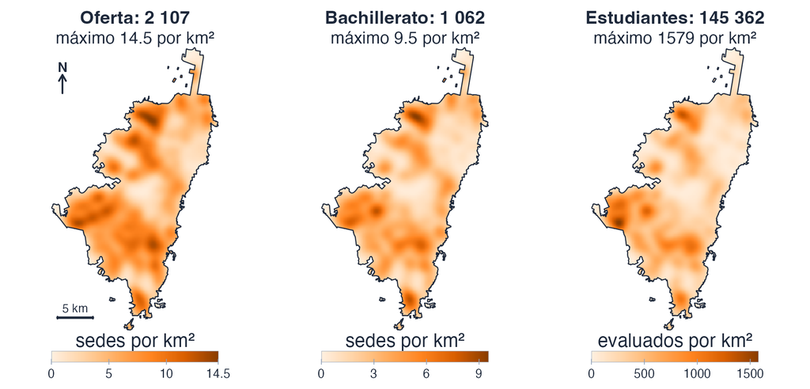

Oferta, bachillerato y estudiantes: tres capas sobre las mismas sedes, cada una a su escala

Fuente: módulo 5 del capítulo (R, spatstat) y figura propia.

Tres capas sobre las mismas sedes

**Qué ilustra:** que «el mapa de calor» no es un solo mapa. **De dónde sale:** las sedes del perímetro urbano (SED) y los evaluados en Saber 11 de 2022 (calendario A); el mismo σ = 720 m (el valor por defecto de `bw.CvL`). **Por qué importa:** el mapa que se publique se leerá como demanda.

Dato

1 062 de las 2 107 sedes (50.4 %) tienen grado 11; son 145 362 evaluados. Correlaciones: oferta–bachillerato **0.943**, oferta–estudiantes **0.862**, bachillerato–estudiantes **0.919**.

Capítulo 5 · Intensidad por núcleosEstadística Espacial · UnBosque31 / 45

La KDE como mapa de calor

## Donde las manchas no coinciden, el edificio y el estudiante dejan de ser lo mismo

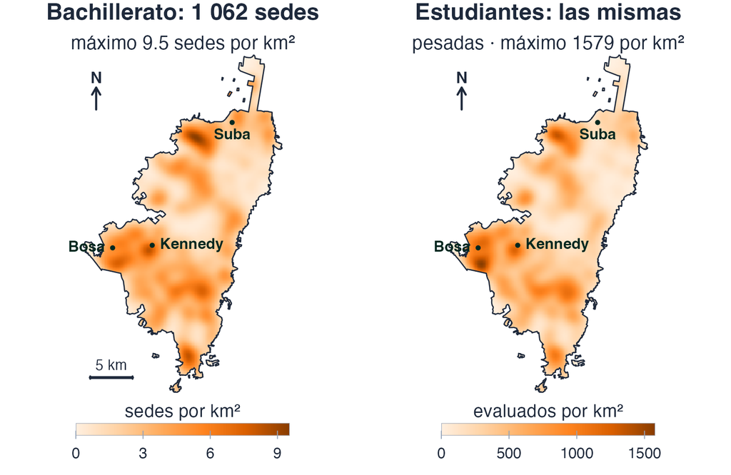

Bachillerato y estudiantes: las mismas 1 062 sedes, con el norte arriba

Fuente: módulo 5 del capítulo (R, spatstat) y figura propia.

Dato

σ = 720 m (el valor por defecto de `bw.CvL`), rejilla de 128 × 218 celdas de 183 m, **cada mapa a su escala**. El máximo de **bachillerato** (9.5 por km²) está en **Suba**; el de **estudiantes** (1579 por km²), en **Bosa**.

Interpretación

Las mismas 1 062 sedes, el mismo σ y la misma rejilla: solo cambia cuánto pesa cada sede (1, o sus evaluados), y por eso el máximo pasa de Suba a Bosa (r = 0.919).

Capítulo 5 · Intensidad por núcleosEstadística Espacial · UnBosque32 / 45

La KDE como mapa de calor

## Con celdas de 183 m, la ciudad no puede dibujar un σ menor que 550 m

Dato · ventana urbana

370.09 km², rejilla de 128 × 218 celdas de 183 m. Regla práctica: celda ≤ σ/3, o sea 3 celdas dentro de σ; con 183.4 m por celda, σ mínimo = 3 × 183.4 = **550 m**.

| Selector | σ sobre la ciudad | ¿Cumple la regla de 3 celdas? |
| --- | --- | --- |
| `bw.diggle` | 373 m | No: menor que 550 m |
| `bw.ppl` | 236 m | No: menor que 550 m |
| `bw.CvL` | **720 m** | Sí: el más estrecho de los que sí |
| `bw.scott` | 1251 m | Sí |

Interpretación

183 m es la celda más fina que el capítulo pudo pagar en el peso de su archivo: con una rejilla más fina, `bw.diggle` y `bw.ppl` sí se podrían dibujar. Por eso el mapa de la ciudad usa `bw.CvL`, y Kennedy, con celdas de 78 m, puede bajar a 233 m.

Criterio

En un análisis propio, primero σ y después la resolución. Aquí se hizo al revés, por el peso del archivo, y por eso se declara: σ = 720 m no lo eligió un criterio estadístico, lo eligió la rejilla.

Fuente: módulo 5 del capítulo (R, spatstat).

Capítulo 5 · Intensidad por núcleosEstadística Espacial · UnBosque33 / 45

Pregunta para la clase

## ¿Cuál de los tres mapas es «el mapa de la demanda educativa»?

1. El de todas las sedes, porque incluye la oferta completa.
2. El de las sedes con grado 11, porque restringe a quien puede atender bachillerato.
3. El de las sedes pesadas por sus evaluados, porque cuenta estudiantes.
4. Ninguno por sí solo: llamarlo así es una decisión, y hay que escribirla.

La 4: ninguno por sí solo

El primero dice dónde hay colegio; el segundo, dónde hay bachillerato; el tercero, dónde están los estudiantes que ya lo cursan. Y un estudiante cuenta donde **estudia**, no donde vive: es demanda **atendida**, no la insatisfecha.

Fuente: módulo 12 del capítulo, autoevaluación `cap5-quiz`.

Capítulo 5 · Intensidad por núcleosEstadística Espacial · UnBosque34 / 45

Universidad El Bosque

Estadística Espacial

Capítulo 5 · Intensidad por núcleos

De contar a suavizar

Núcleo y ancho de banda: dos decisiones

Selectores de ancho de banda

Corrección de borde en la KDE

La KDE como mapa de calor

Intensidad relativa

Cierre y práctica

06

## Intensidad relativa

Muchas preguntas reales no van de cuántos hay, sino de qué proporción: dónde pesan más los casos que los controles, dónde pesa más lo público que lo privado.

Leer en el material: Intensidad relativa

35 / 45

Intensidad relativa

## La proporción es el cociente de dos KDE con el mismo ancho

Ahora cada punto trae una **marca**, su tipo (caso o control, oficial o privada), y estimamos una KDE por tipo.

$$\hat p(u) \;=\; \frac{\hat\lambda_1(u)}{\hat\lambda_1(u) + \hat\lambda_0(u)}$$

- \(\hat p(u)\): dado que en \(u\) hay un evento, la **probabilidad de que sea del tipo 1**; vive entre 0 y 1
- El riesgo relativo, \(\hat r = \hat\lambda_1/\hat\lambda_0\), vive entre 0 e infinito y \(\hat p = \hat r/(1+\hat r)\)

Interpretación

La misma información en otra escala. `relrisk` devuelve la probabilidad, salvo que se le pida `relative = TRUE`.

Criterio

Las dos KDE van sobre la misma ventana y con el mismo σ. Con la corrección por defecto, e(u) **se cancela**: numerador y denominador la llevan igual; con Diggle, no.

Fuente: módulo 6 del capítulo (fórmula del capítulo).

Capítulo 5 · Intensidad por núcleosEstadística Espacial · UnBosque36 / 45

Intensidad relativa

## Chorley: 58 casos de laringe contra 978 controles de pulmón

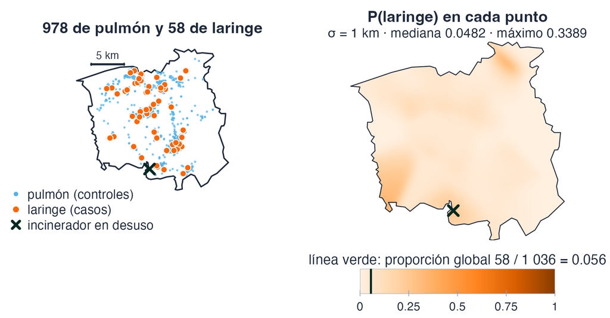

Chorley: los domicilios y la superficie P(laringe), con escala de 0 a 1

Dato

Global 58 / 1 036 = **0.0560**; mediana de la superficie **0.0482**; máximo **0.3389**, donde casi no hay puntos: 4 de sus 50 vecinos más próximos son casos.

Fuente: módulo 6 del capítulo (R, spatstat.data) y figura propia.

Chorley y South Ribble

**Qué ilustra:** un cociente de intensidades con casos y controles. **De dónde sale:** `chorley` (spatstat.data): 58 casos de laringe y 978 de pulmón, Lancashire, 1974–1983, en 315.16 km². **Por qué importa:** Diggle (1990) buscaba más cáncer de laringe cerca de un incinerador en desuso (la ×); el pulmón marca dónde vive la población en riesgo.

Criterio

No se titula con el máximo de un cociente: se mira cuántos puntos lo sostienen. Los controles son de **pulmón**, no población sana.

Capítulo 5 · Intensidad por núcleosEstadística Espacial · UnBosque37 / 45

Pregunta para la clase

## Los casos se llaman `larynx` y los controles `lung`. ¿Qué probabilidad pinta `relrisk`?

1. Las dos a la vez, como dos superficies complementarias.
2. P(laringe), porque `larynx` va primero.
3. P(pulmón), porque los niveles se ordenan alfabéticamente y `relrisk` pinta el del segundo.
4. Depende de σ, porque decide qué nivel domina el cociente.

La 3: P(pulmón)

Los niveles de un factor se ordenan alfabéticamente: en `larynx, lung` el segundo es «lung». Sin tocar nada, el mapa de `chorley` es P(pulmón): la mediana sale 0.9518 en vez de 0.0482. σ cambia lo suave que sale el mapa, no de qué nivel es la probabilidad.

Fuente: módulo 6 del capítulo (R, spatstat.data); pregunta propia, variante de la autoevaluación `cap5-trampas`.

Capítulo 5 · Intensidad por núcleosEstadística Espacial · UnBosque38 / 45

Intensidad relativa

## La trampa: todo corre, nada avisa y el mapa sale al revés

Fijar el orden de los niveles

```
ch <- chorley
marks(ch) <- factor(as.character(marks(chorley)),
                    levels = c("lung", "larynx"))
rr <- relrisk(ch, sigma = 1)
v <- as.numeric(rr$v); v <- v[is.finite(v)]

round(c(mediana = median(v),
        global = mean(marks(ch) == "larynx"),
        maxima = max(v)), 4)
#> mediana  global  maxima
#>  0.0482  0.0560  0.3389
```

Dato · chorley

Sin fijar el orden, el mapa de `chorley` es **P(pulmón)**: la mediana sale 0.9518 en vez de 0.0482. Con el orden fijado, en el máximo los 50 vecinos más próximos son casos en un **8 %** (4 de 50) contra **5.6 %** en el conjunto.

Criterio

Dos comprobaciones a la vez: **fijar el orden** de los niveles y **comprobar la orientación contra el dato**: el tipo debe pesar más entre los vecinos del máximo que en todo el conjunto.

Fuente: módulo 6 del capítulo (R, spatstat.data).

Capítulo 5 · Intensidad por núcleosEstadística Espacial · UnBosque39 / 45

Intensidad relativa

## En Bogotá no es riesgo, es proporción de tipo: nadie «contrae» ser oficial

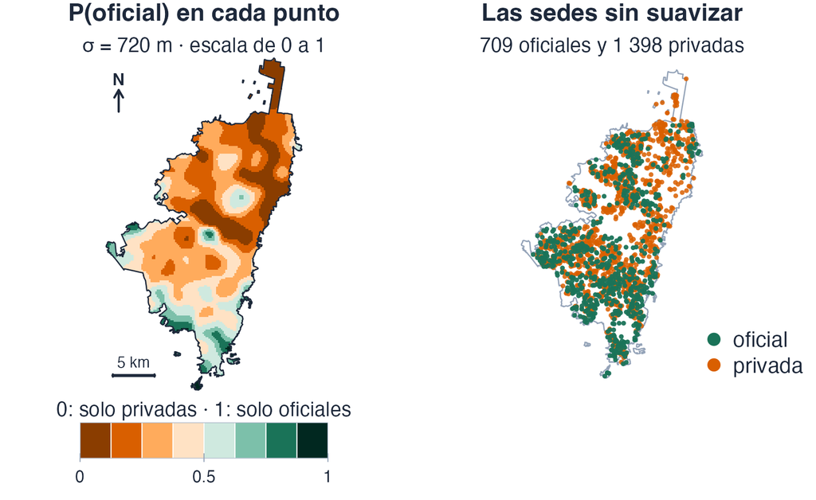

P(oficial) y las sedes por sector, con el norte arriba

Fuente: módulo 6 del capítulo (R, spatstat) y figura propia.

Oficial contra privado

**Qué ilustra:** la misma matemática leyendo otra cosa. **De dónde sale:** las 2 107 sedes urbanas por sector (SED); σ = 720 m (el valor por defecto de `bw.CvL`). **Por qué importa:** hay dos poblaciones completas, no casos y controles.

Dato

**709** oficiales + **1 398** privadas = 2 107. Escala fija de 0 a 1, y el verde empieza en 0.5: lo verde es mayoría oficial. En el máximo de P(oficial), los 50 vecinos más próximos son oficiales en un **64 %** (32 de 50) contra **33.65 %** en el conjunto.

Capítulo 5 · Intensidad por núcleosEstadística Espacial · UnBosque40 / 45

Intensidad relativa

## Contar puntos da 0.3365; mirar el mapa da 0.3090: son dos preguntas distintas

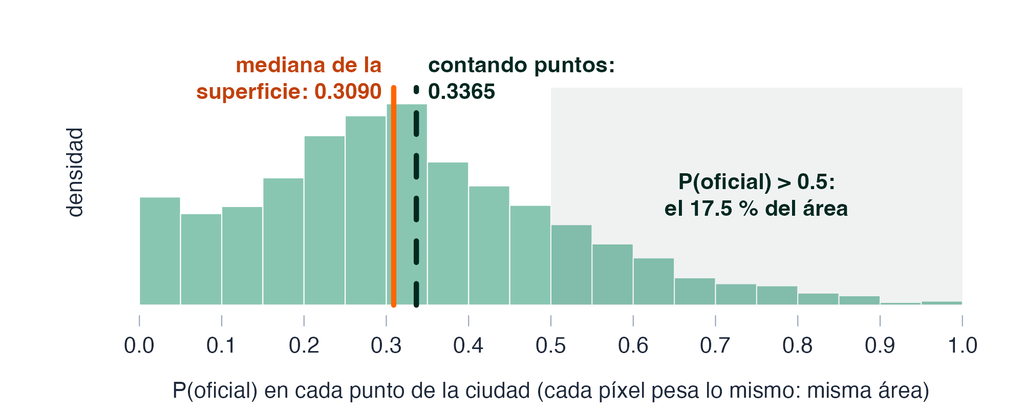

La superficie P(oficial), con su mediana y la proporción de los puntos

Dato · las 2 107 sedes urbanas

709 / 2 107 = **0.3365** (contando puntos). Mediana de la superficie P(oficial) = **0.3090** (contando área). Las oficiales son mayoría, con P(oficial) > 0.5, en el **17.5 %** del área.

Interpretación

La mediana del área queda por debajo de la proporción de los puntos: poco (0.028), pero no por azar, y las dos cifras contestan preguntas distintas. La respuesta directa a «¿en qué fracción de la ciudad son mayoría?» es el 17.5 %.

Fuente: módulo 6 del capítulo (R, spatstat) y figura propia.

Capítulo 5 · Intensidad por núcleosEstadística Espacial · UnBosque41 / 45

Universidad El Bosque

Estadística Espacial

Capítulo 5 · Intensidad por núcleos

De contar a suavizar

Núcleo y ancho de banda: dos decisiones

Selectores de ancho de banda

Corrección de borde en la KDE

La KDE como mapa de calor

Intensidad relativa

Cierre y práctica

07

## Cierre y práctica

Leer en el material: Autoevaluación y ejercicios

42 / 45

Tesis de la sesión

## Una superficie de intensidad es la respuesta a una pregunta que alguien formuló

Con qué ancho, con qué corrección de borde, sobre qué ventana y con qué peso por punto: hoy vimos dónde vive cada decisión y qué pasa cuando no se escribe.

Fuente: módulo 12 del capítulo (tesis del autor).

Capítulo 5 · Intensidad por núcleosEstadística Espacial · UnBosque43 / 45

Cierre y práctica

## Dónde vive cada decisión

- La **ventana**: `ppp(window = W)`; un borde es una decisión
- El **ancho**: `sigma =`; se declara quién lo eligió (`bw.*`), y ninguno entrega «el óptimo»
- El **núcleo**: `kernel =`; casi no mueve el mapa (un 5.1 % a σ = 400 m en Kennedy)
- El **borde**: `edge =` y `diggle =`; se declara qué conserva la integral, que se compara con n
- El **peso** de cada punto: `weights =`; qué cuenta el mapa
- El **nivel** que pinta un cociente: `case =` en `relrisk`, o el orden de los niveles; se comprueba contra el dato

Todo mapa de intensidad se entrega con su ventana, su σ y quién lo eligió, su corrección de borde y lo que pesa cada punto. Fuente: módulo 2 del capítulo, para el 5.1 %.

Javier Mauricio Sierra

Capítulo 5 · Intensidad por núcleosEstadística Espacial · UnBosque44 / 45

Cierre y práctica

## Práctica: dos ejercicios guiados, el simulacro del Quiz 2 y la próxima sesión

1Ejercicio 1 · El selector que no seleccionólos cuatro selectores sobre `japanesepines`, `redwood` y `swedishpines`; encontrar cuál de los doce valores es la pared de su intervalo y no un óptimo

→

2Ejercicio 2 · La masa que se escapa`chorley`, con σ = 0.5, 1 y 2: la integral de las tres correcciones contra n

→

3Simulacro del Quiz 2 (módulo 13)con el reloj puesto y sin abrir nada; se contrasta en clase. El Quiz 2 cubre las cuatro primeras secciones de hoy, hasta la corrección de borde

→

4Próxima sesiónde dibujar la intensidad a modelarla: covariables, `ppm`, diagnóstico y conglomerados

Fuente: módulo 12 del capítulo, ejercicios guiados 1 y 2, y simulacro del módulo 13.

Capítulo 5 · Intensidad por núcleosEstadística Espacial · UnBosque45 / 45

[output not shown]

·

00:00

A continuación

Notas